# Metabolomics Analysis

Next, let’s convert to the relabund data to a bray curtis distance matrix, run a NMDS and PERMANOVA. We will then compare to the same process with raw abundance data data.

```r
#work up relabund data for vegdist
rownames(relabund.19.jun.clean2)=relabund.19.jun.clean2$row.ID
relabund.19.jun.clean2.dist=relabund.19.jun.clean2[,7:63]
relabund.19.jun.clean2.dist.t=as.data.frame(t(relabund.19.jun.clean2.dist))

#work up the abund data for vegdist
rownames(data.19.jun.clean2)=data.19.jun.clean2$row.ID
data.19.jun.clean2.dist=data.19.jun.clean2[,7:63]
data.19.jun.clean2.dist.t=as.data.frame(t(data.19.jun.clean2.dist))

bray.relabund.19.jun.clean2=vegdist(relabund.19.jun.clean2.dist.t,method="bray")
bray.19.jun.clean2=vegdist(data.19.jun.clean2.dist.t,method="bray")

nmds.relabund=metaMDS(bray.relabund.19.jun.clean2,k=2,trymax=100)
```

```
## *** Solution reached
```

```r
#Convergent solutions were reached and stress was ok (~.17)

nmds=metaMDS(bray.19.jun.clean2,k=2,trymax=100)
```

```
## *** Solution reached
```

```r
#Convergent solutions were reached and stress was good (~.13)

pointvec=c(15,16,17) #generate a vector of points to correspond to Species.
colvec=viridis(n=4,option="D")

#adjust the oder of the metadata samples to correspond to the order of samples in the dist matrix
metadata.19.jun.samples1=metadata.19.jun.samples[match(rownames(data.19.jun.clean2.dist.t),metadata.19.jun.samples$sample_name2),]

plot(nmds.relabund,type="n",main="relabund",xlim=c(-.8,.5))
```

```
## species scores not available
```

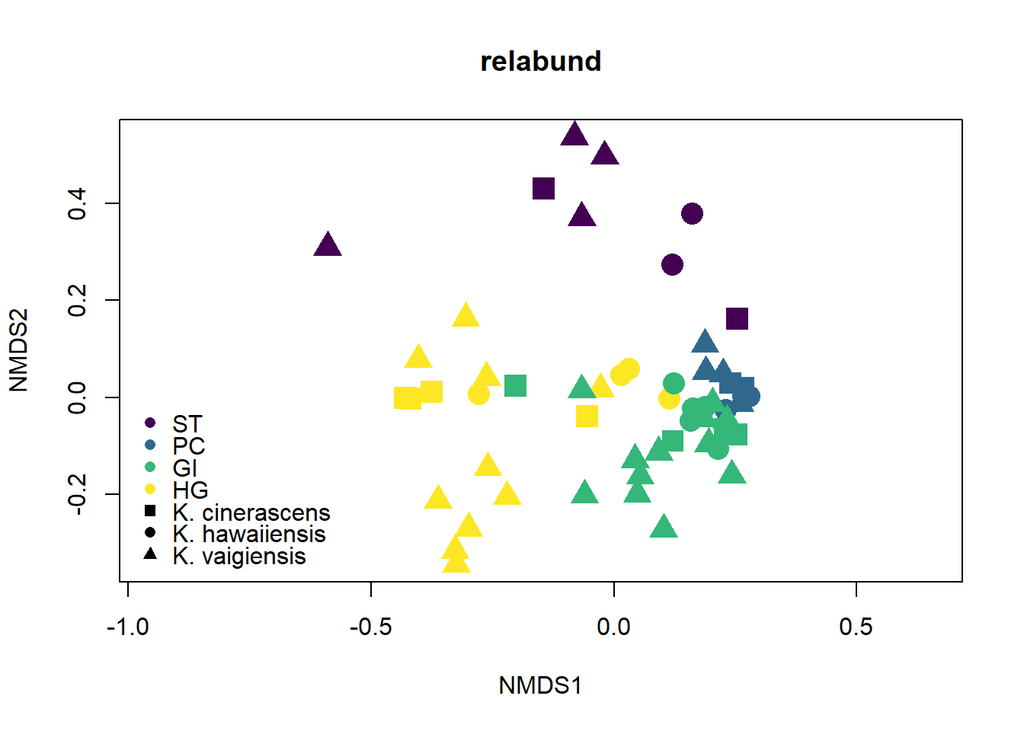

```r
points(nmds.relabund, #plot each sample as a point
       cex=2,
       pch=pointvec[metadata.19.jun.samples1$Species], #point shape corresponds to fish Species
       col=colvec[metadata.19.jun.samples1$Gut_Section])
legend(-1,0,legend = c("ST","PC","GI","HG","K. cinerascens","K. hawaiiensis","K. vaigiensis"),cex=1,y.intersp=.75,bg="transparent",bty="n",col=c(colvec,"black","black","black"),pch=c(16,16,16,16,15,16,17),pt.cex=1)
```

```r
plot(nmds,type="n",main="raw abundance",xlim=c(-.8,.5))
```

```
## species scores not available
```

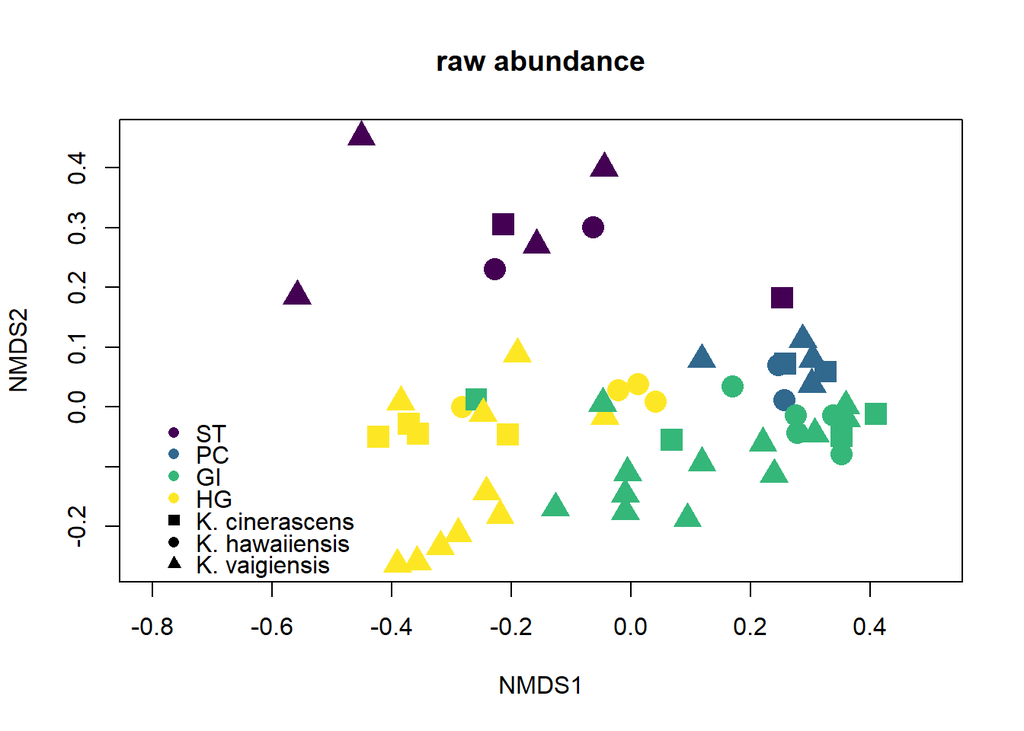

```r
points(nmds, #plot each sample as a point
       cex=2,
       pch=pointvec[metadata.19.jun.samples1$Species], #point shape corresponds to fish Species
       col=colvec[metadata.19.jun.samples1$Gut_Section])
legend(-.8,0,legend = c("ST","PC","GI","HG","K. cinerascens","K. hawaiiensis","K. vaigiensis"),cex=1,y.intersp=.75,bg="transparent",bty="n",col=c(colvec,"black","black","black"),pch=c(16,16,16,16,15,16,17),pt.cex=1)
```

Regardless of if I use raw abundance or relative abundance data, the NMDS shows clear distinction in metabolomic communities by gut section. Hard to tell if species has an effect. Now I will run permanovas on the relabund dist matrix to asses the effects of Gut_Section and Species on metabolomic communities. Looks like the dispersion patterns here do not reflect the microbial community patterns. ST and HG have highest dispersion while GI and especially PC have low dispersion. I cannot explain the ST, GI, and HG patterns but it is likely that the PC has such low dispersion because we didn’t sample any digesta from that section (or very little), so the signal is mostly fish tissue which is likely more uniform between individuals?

```r
permanova.gut.section=adonis(relabund.19.jun.clean2.dist.t~Gut_Section*Species,by="margin",strata=metadata.19.jun.samples1$ATTRIBUTE_Fish_Number,data=metadata.19.jun.samples1)
permanova.gut.section
```

```
##
## Call:
## adonis(formula = relabund.19.jun.clean2.dist.t ~ Gut_Section *      Species, data = metadata.19.jun.samples1, strata = metadata.19.jun.samples1$ATTRIBUTE_Fish_Number,      by = "margin")
##
## Blocks:  strata
## Permutation: free
## Number of permutations: 999
##
## Terms added sequentially (first to last)
##
##                     Df SumsOfSqs MeanSqs F.Model      R2 Pr(>F)
## Gut_Section          3    4.3111 1.43704  8.6695 0.30479  0.001 ***
## Species              3    1.2996 0.43322  2.6135 0.09188  0.001 ***
## Gut_Section:Species  6    1.2403 0.20672  1.2471 0.08769  0.030 *
## Residuals           44    7.2934 0.16576         0.51564
## Total               56   14.1444                 1.00000
## ---
## Signif. codes:  0 '***' 0.001 '**' 0.01 '*' 0.05 '.' 0.1 ' ' 1
```

```r
permanova.gut.section.II=adonis.II(relabund.19.jun.clean2.dist.t~Gut_Section*Species,by="margin",strata=metadata.19.jun.samples1$ATTRIBUTE_Fish_Number,data=metadata.19.jun.samples1)
permanova.gut.section.II
```

```
## Blocks:  strata
## Permutation: free
## Number of permutations: 999
##
## Type II tests
## Response: relabund.19.jun.clean2.dist.t
##                      Sum Sq Mean Sq Df      F Pr(>F)
## Gut_Section          4.2657 1.42191  3 8.5782  0.001 ***
## Species              1.2996 0.43322  3 2.6135  0.001 ***
## Gut_Section:Species  1.2403 0.20672  6 1.2471  0.036 *
## Residuals            7.2934 0.16576 44
## Total               14.1444         56
## ---
## Signif. codes:  0 '***' 0.001 '**' 0.01 '*' 0.05 '.' 0.1 ' ' 1
```

Gut Section is the most significant predictor of metabolomic community structure, followed by Species and a barely significant interaction between the two. Gut_Section explained the most variability.

Now I will analyze only the dataset that corresponds to the 16S multivariate dataset, looking at gut subsection instead of gut section.

```r
#read in unifrac metadata
metadata.fish.F4.F8.unifrac=read.csv(file="metadata.fish.F4.F8.unifrac.csv")
metadata.19.jun.samples2=merge(metadata.19.jun.samples1,metadata.fish.F4.F8.unifrac,by.x="SampleCode",by.y="SampleCode")

relabund.19.jun.clean2.dist.t.2=relabund.19.jun.clean2.dist.t[rownames(relabund.19.jun.clean2.dist.t) %in% metadata.19.jun.samples2$sample_name2,]

#There are 2 samples in the metadata.fish.F4.F8.unifrac df that are not in the metadata.19.jun.samples1 df. These are "F8_GI_3" and "F6_GI_3". Confirm with Emily what happened to them.

#Generate dist matrix
bray.relabund.19.jun.clean2.2=vegdist(relabund.19.jun.clean2.dist.t.2,method="bray")

#reorder the metadata so it lines up with the distance matrix
metadata.19.jun.samples2=metadata.19.jun.samples2[match(rownames(relabund.19.jun.clean2.dist.t.2),metadata.19.jun.samples2$sample_name2),]
colnames(metadata.19.jun.samples2)[5]="Species"
colnames(metadata.19.jun.samples2)[6]="Gut_Section"
colnames(metadata.19.jun.samples2)[7]="Gut_SubSection"


nmds.relabund.2=metaMDS(bray.relabund.19.jun.clean2.2,k=2,trymax=100)
```

```
## *** Solution reached
```

```r
#convergent solution reached, decent stress (.17)

colvec3=viridis(n=8,option="D")

plot(nmds.relabund.2,type="n")
```

```
## species scores not available
```

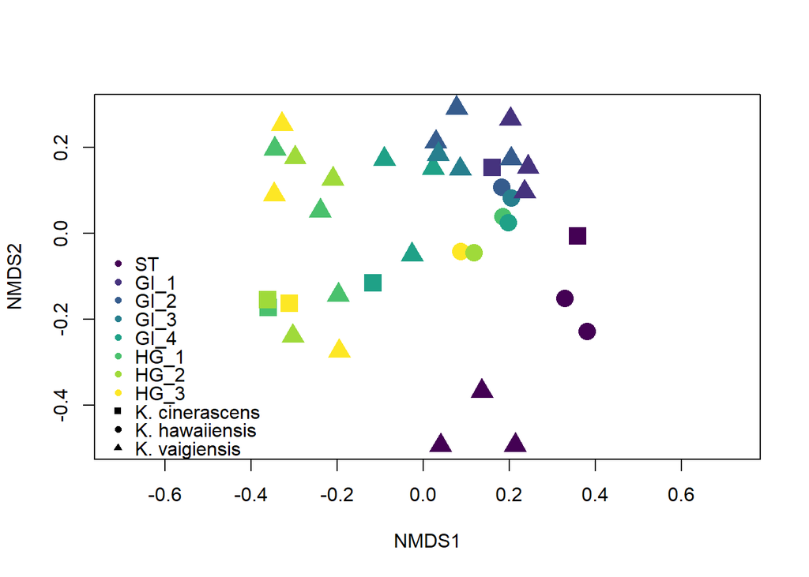

```r
points(nmds.relabund.2, #plot each sample as a point
       cex=2,
       pch=pointvec[metadata.19.jun.samples2$Species], #point shape corresponds to fish Species
       col=colvec3[metadata.19.jun.samples2$Gut_SubSection])
legend(-.75,-.022,legend = c("ST","GI_1","GI_2","GI_3","GI_4","HG_1","HG_2","HG_3","K. cinerascens","K. hawaiiensis","K. vaigiensis"),cex=1,y.intersp=.8,bg="transparent",bty="n",col=c(colvec3,"black","black","black"),pch=c(16,16,16,16,16,16,16,16,15,16,17),pt.cex=.75)
```

We can see a clear succesional gradient from ST -> HG_3, and also more clearly see that species cluster distinctly, especially K. hawaiiensis.

Now, I will run a permanova on this dataset.

```r
permanova.gut.subsection=adonis(relabund.19.jun.clean2.dist.t.2~Gut_SubSection*Species,by="margin",strata=metadata.19.jun.samples2$ATTRIBUTE_Fish_Number,data=metadata.19.jun.samples2,permutations=999)
permanova.gut.subsection
```

```
##
## Call:
## adonis(formula = relabund.19.jun.clean2.dist.t.2 ~ Gut_SubSection *      Species, data = metadata.19.jun.samples2, permutations = 999,      strata = metadata.19.jun.samples2$ATTRIBUTE_Fish_Number,      by = "margin")
##
## Blocks:  strata
## Permutation: free
## Number of permutations: 999
##
## Terms added sequentially (first to last)
##
##                        Df SumsOfSqs MeanSqs F.Model      R2 Pr(>F)
## Gut_SubSection          7    3.2040 0.45771  2.5426 0.33887  0.001 ***
## Species                 2    1.6007 0.80036  4.4461 0.16930  0.001 ***
## Gut_SubSection:Species 11    1.7698 0.16089  0.8938 0.18719  0.025 *
## Residuals              16    2.8802 0.18001         0.30463
## Total                  36    9.4548                 1.00000
## ---
## Signif. codes:  0 '***' 0.001 '**' 0.01 '*' 0.05 '.' 0.1 ' ' 1
```

```r
permanova.gut.subsection.II=adonis.II(relabund.19.jun.clean2.dist.t.2~Gut_SubSection*Species,by="margin",strata=metadata.19.jun.samples2$ATTRIBUTE_Fish_Number,data=metadata.19.jun.samples2,permutations=999)
permanova.gut.subsection.II
```

```
## Blocks:  strata
## Permutation: free
## Number of permutations: 999
##
## Type II tests
## Response: relabund.19.jun.clean2.dist.t.2
##                        Sum Sq Mean Sq Df      F Pr(>F)
## Gut_SubSection         3.1908 0.45582  7 2.5321  0.001 ***
## Species                1.6007 0.80036  2 4.4461  0.001 ***
## Gut_SubSection:Species 1.7698 0.16089 11 0.8938  0.029 *
## Residuals              2.8802 0.18001 16
## Total                  9.4548         36
## ---
## Signif. codes:  0 '***' 0.001 '**' 0.01 '*' 0.05 '.' 0.1 ' ' 1
```

Gut subsection and Species are both very significant, whereas the interaction term is less (but still noticably) significant. Gut subsection explains double the variation of species or their interaction. Interestingly, the interaction term explains more variation than species alone, despite the low effect size (F value).

Next, I will import the parallel 16S distance matrix, and compare the 2 using procrustes and mantel tests.

```r
#Read in the 16S dist matrix, and subset it so it only includes the corresponding metabolomic samples
weighted.unifrac.F4.F8.matrix=read.csv(file="weighted.unifrac.matrix.F4.F8.matrix.csv")
rownames(weighted.unifrac.F4.F8.matrix)=weighted.unifrac.F4.F8.matrix$X
weighted.unifrac.F4.F8.matrix=weighted.unifrac.F4.F8.matrix[,-1]
weighted.unifrac.F4.F8.matrix1=weighted.unifrac.F4.F8.matrix[rownames(weighted.unifrac.F4.F8.matrix)!="F6_GI_3"&rownames(weighted.unifrac.F4.F8.matrix)!="F8_GI_3",colnames(weighted.unifrac.F4.F8.matrix)!="F6_GI_3"&rownames(weighted.unifrac.F4.F8.matrix)!="F8_GI_3"]
#re order the matrix so samples are in the same order as the metabolomic dist matrix
weighted.unifrac.F4.F8.matrix1=weighted.unifrac.F4.F8.matrix1[match(metadata.19.jun.samples2$SampleCode,rownames(weighted.unifrac.F4.F8.matrix1)),match(metadata.19.jun.samples2$SampleCode,rownames(weighted.unifrac.F4.F8.matrix1))]
weighted.unifrac.F4.F8.dist1=as.dist(weighted.unifrac.F4.F8.matrix1) #convert to dist

mantel(weighted.unifrac.F4.F8.dist1,bray.relabund.19.jun.clean2.2)
```

```
##
## Mantel statistic based on Pearson's product-moment correlation
##
## Call:
## mantel(xdis = weighted.unifrac.F4.F8.dist1, ydis = bray.relabund.19.jun.clean2.2)
##
## Mantel statistic r: 0.4336
##       Significance: 0.001
##
## Upper quantiles of permutations (null model):
##    90%    95%  97.5%    99%
## 0.0708 0.0950 0.1231 0.1522
## Permutation: free
## Number of permutations: 999
```

```r
#Generate a nmds from the 16S dist matrix
nmds.16s=metaMDS(weighted.unifrac.F4.F8.dist1,k=2,trymax=10)
```

```
## *** Solution reached
```

```r
#plot the 16S nmds
plot(nmds.16s,type="n",main="16S")
```

```
## species scores not available
```

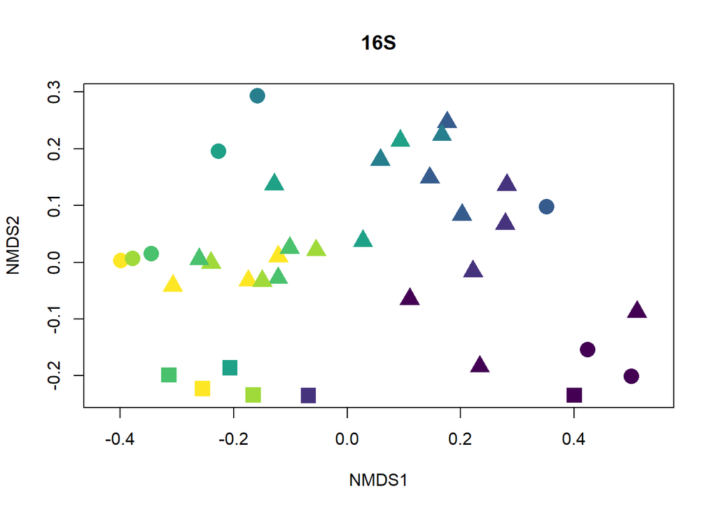

```r
points(nmds.16s, #plot each sample as a point
       cex=2,
       pch=pointvec[metadata.19.jun.samples2$Species], #point shape corresponds to fish Species
       col=colvec3[metadata.19.jun.samples2$Gut_SubSection])
```

```r
#replot the metabolomics nmds for comparison
plot(nmds.relabund.2,type="n",main="Metabolomics")
```

```
## species scores not available
```

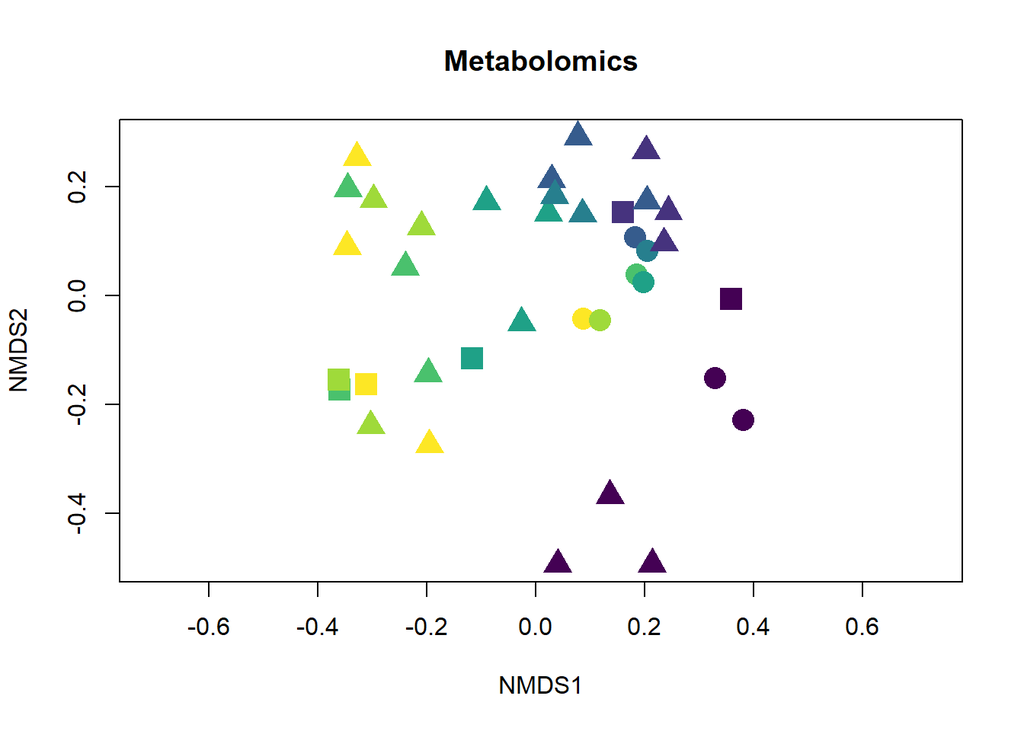

```r
points(nmds.relabund.2, #plot each sample as a point
       cex=2,
       pch=pointvec[metadata.19.jun.samples2$Species], #point shape corresponds to fish Species
       col=colvec3[metadata.19.jun.samples2$Gut_SubSection])
```

```r
#as you can see, it looks like there is potential to align the two nmds plots pretty well.

#run procrustes on the two nmds objects
pro=procrustes(nmds.16s,nmds.relabund.2,scale=FALSE,symmetric=TRUE,scores="sites")
summary(pro)
```

```
##
## Call:
## procrustes(X = nmds.16s, Y = nmds.relabund.2, scale = FALSE,      symmetric = TRUE, scores = "sites")
##
## Number of objects: 37    Number of dimensions: 2
##
## Procrustes sum of squares:
##  0.8332987
## Procrustes root mean squared error:
##  0.1500719
## Quantiles of Procrustes errors:
##         Min          1Q      Median          3Q         Max
## 0.009090704 0.074395744 0.104073074 0.163979444 0.289523514
##
## Rotation matrix:
##            [,1]      [,2]
## [1,]  0.9949276 0.1005941
## [2,] -0.1005941 0.9949276
##
## Translation of averages:
##              [,1]          [,2]
## [1,] 5.516389e-19 -2.766837e-19
##
## Scaling of target:
## [1] 1
```

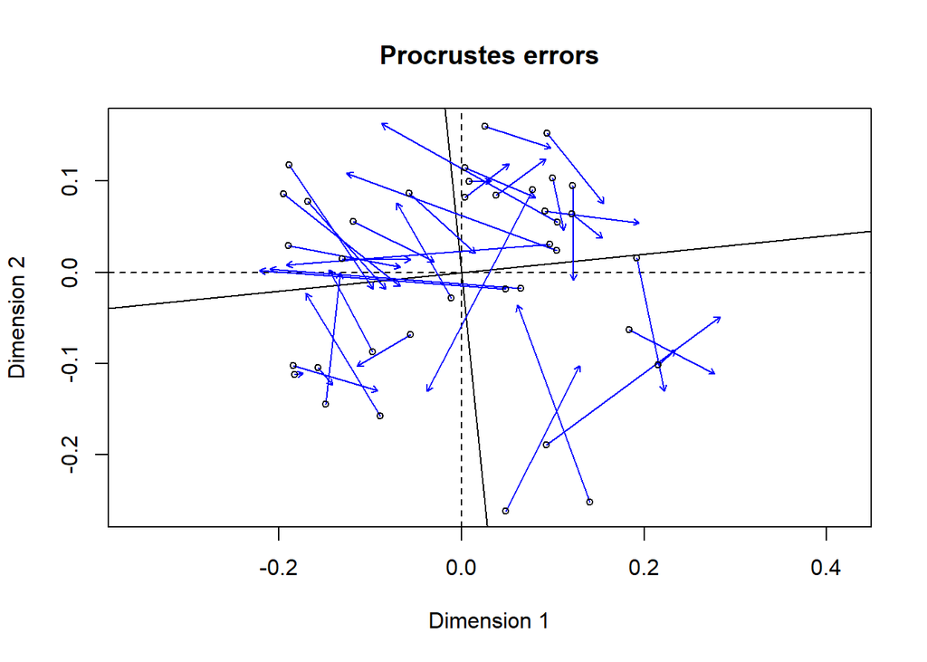

```r
#first do the simple plots
plot(pro,kind=1)
```

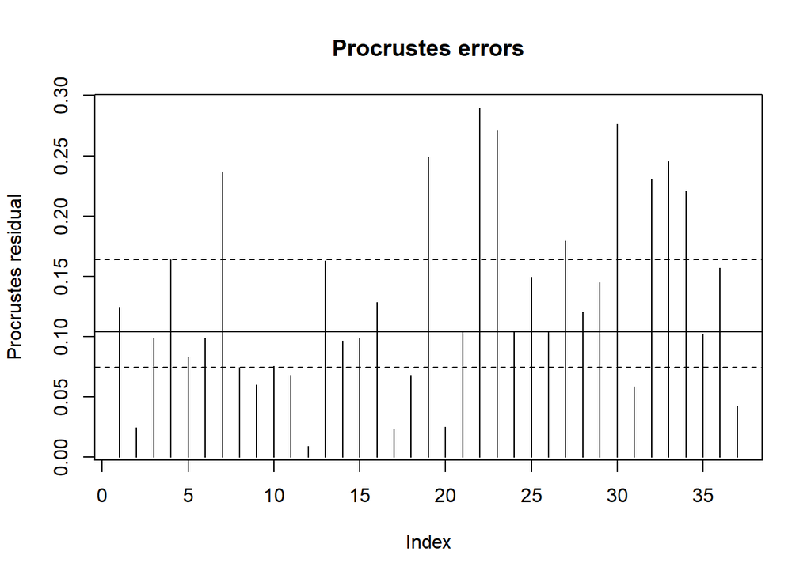

```r
plot(pro,kind=2) #Not sure how to interperet this.
```

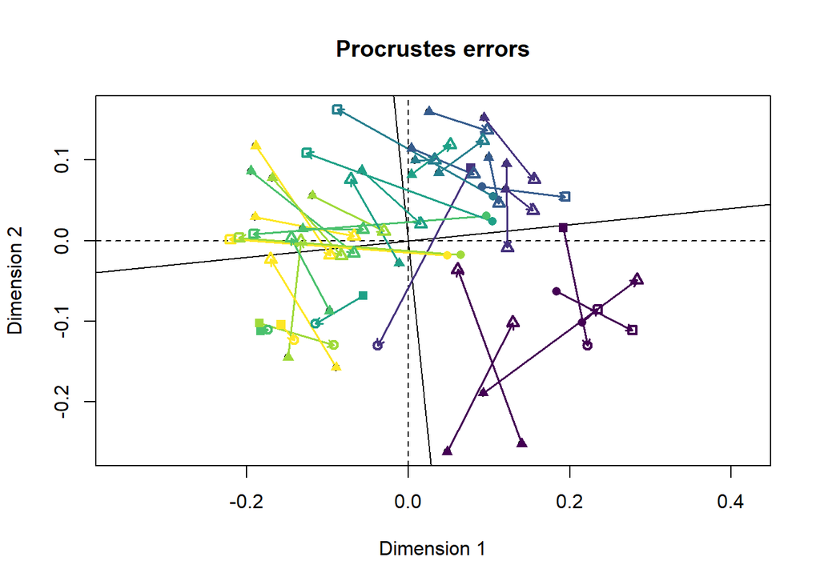

```r
pointvec2=c(21,22,24)

#next plot a more detailed procrustes plot, with the filled points representing the rotated (metabolomic) samples and the open points representing the target (16S) samples.
plot(pro,kind=1,lwd=1.5,len=.06,ar.col=colvec3[metadata.19.jun.samples2$Gut_SubSection])
points(pro, display="rotated",#plot each sample as a point
       cex=1,
       pch=pointvec[metadata.19.jun.samples2$Species], #point shape corresponds to fish Species
       col=colvec3[metadata.19.jun.samples2$Gut_SubSection])
points(pro, display="target",#plot each sample as a point
       cex=1,
       lwd=2,
       pch=pointvec2[metadata.19.jun.samples2$Species], #point shape corresponds to fishSpecies
       col=colvec3[metadata.19.jun.samples2$Gut_SubSection])
```

```r
pro.test=protest(nmds.16s,nmds.relabund.2,scores="sites")
pro.test
```

```
##
## Call:
## protest(X = nmds.16s, Y = nmds.relabund.2, scores = "sites")
##
## Procrustes Sum of Squares (m12 squared):        0.6597
## Correlation in a symmetric Procrustes rotation: 0.5834
## Significance:  0.001
##
## Permutation: free
## Number of permutations: 999
```

The protest comes out as “significant”, but I am not sure how useful the pvalue is. Need to read up more on the procrustes SS and correlation statistics.